# Risk Factor Analysis

## Outcome Variable

**Outcome Variable:** ever_wasted

## Predictor Variables

**Intervention Variable:** fhtcm

**Adjustment Set:**

unadjusted

## Stratifying Variables

The analysis was stratified on these variable(s):

- agecat
- studyid
- country

## Data Summary

| agecat | studyid | country | fhtcm | ever_wasted | n_cell | n |
| --- | --- | --- | --- | --- | --- | --- |
| 0-24 months | ki1000304b-SAS-CompFeed | INDIA | >=167 cm | 0 | 255 | 895 |
| 0-24 months | ki1000304b-SAS-CompFeed | INDIA | >=167 cm | 1 | 152 | 895 |
| 0-24 months | ki1000304b-SAS-CompFeed | INDIA | <162 cm | 0 | 130 | 895 |
| 0-24 months | ki1000304b-SAS-CompFeed | INDIA | <162 cm | 1 | 96 | 895 |
| 0-24 months | ki1000304b-SAS-CompFeed | INDIA | [162-167) cm | 0 | 145 | 895 |
| 0-24 months | ki1000304b-SAS-CompFeed | INDIA | [162-167) cm | 1 | 117 | 895 |
| 0-24 months | ki1000304b-SAS-FoodSuppl | INDIA | >=167 cm | 0 | 53 | 399 |
| 0-24 months | ki1000304b-SAS-FoodSuppl | INDIA | >=167 cm | 1 | 53 | 399 |
| 0-24 months | ki1000304b-SAS-FoodSuppl | INDIA | <162 cm | 0 | 75 | 399 |
| 0-24 months | ki1000304b-SAS-FoodSuppl | INDIA | <162 cm | 1 | 88 | 399 |
| 0-24 months | ki1000304b-SAS-FoodSuppl | INDIA | [162-167) cm | 0 | 83 | 399 |
| 0-24 months | ki1000304b-SAS-FoodSuppl | INDIA | [162-167) cm | 1 | 47 | 399 |
| 0-24 months | ki1101329-Keneba | GAMBIA | >=167 cm | 0 | 674 | 1933 |
| 0-24 months | ki1101329-Keneba | GAMBIA | >=167 cm | 1 | 574 | 1933 |
| 0-24 months | ki1101329-Keneba | GAMBIA | <162 cm | 0 | 69 | 1933 |
| 0-24 months | ki1101329-Keneba | GAMBIA | <162 cm | 1 | 63 | 1933 |
| 0-24 months | ki1101329-Keneba | GAMBIA | [162-167) cm | 0 | 291 | 1933 |
| 0-24 months | ki1101329-Keneba | GAMBIA | [162-167) cm | 1 | 262 | 1933 |
| 0-24 months | ki1119695-PROBIT | BELARUS | >=167 cm | 0 | 8471 | 12537 |
| 0-24 months | ki1119695-PROBIT | BELARUS | >=167 cm | 1 | 3273 | 12537 |
| 0-24 months | ki1119695-PROBIT | BELARUS | <162 cm | 0 | 121 | 12537 |
| 0-24 months | ki1119695-PROBIT | BELARUS | <162 cm | 1 | 47 | 12537 |
| 0-24 months | ki1119695-PROBIT | BELARUS | [162-167) cm | 0 | 444 | 12537 |
| 0-24 months | ki1119695-PROBIT | BELARUS | [162-167) cm | 1 | 181 | 12537 |
| 0-24 months | ki1135781-COHORTS | GUATEMALA | >=167 cm | 0 | 54 | 495 |
| 0-24 months | ki1135781-COHORTS | GUATEMALA | >=167 cm | 1 | 9 | 495 |
| 0-24 months | ki1135781-COHORTS | GUATEMALA | <162 cm | 0 | 224 | 495 |
| 0-24 months | ki1135781-COHORTS | GUATEMALA | <162 cm | 1 | 69 | 495 |
| 0-24 months | ki1135781-COHORTS | GUATEMALA | [162-167) cm | 0 | 105 | 495 |
| 0-24 months | ki1135781-COHORTS | GUATEMALA | [162-167) cm | 1 | 34 | 495 |

[output cut: 60 more lines]

The following strata were considered:

- agecat: 0-24 months, studyid: ki1000304b-SAS-CompFeed, country: INDIA
- agecat: 0-24 months, studyid: ki1000304b-SAS-FoodSuppl, country: INDIA
- agecat: 0-24 months, studyid: ki1101329-Keneba, country: GAMBIA
- agecat: 0-24 months, studyid: ki1119695-PROBIT, country: BELARUS
- agecat: 0-24 months, studyid: ki1135781-COHORTS, country: GUATEMALA
- agecat: 0-6 months, studyid: ki1000304b-SAS-CompFeed, country: INDIA
- agecat: 0-6 months, studyid: ki1000304b-SAS-FoodSuppl, country: INDIA
- agecat: 0-6 months, studyid: ki1101329-Keneba, country: GAMBIA
- agecat: 0-6 months, studyid: ki1119695-PROBIT, country: BELARUS
- agecat: 0-6 months, studyid: ki1135781-COHORTS, country: GUATEMALA
- agecat: 6-24 months, studyid: ki1000304b-SAS-CompFeed, country: INDIA
- agecat: 6-24 months, studyid: ki1000304b-SAS-FoodSuppl, country: INDIA
- agecat: 6-24 months, studyid: ki1101329-Keneba, country: GAMBIA
- agecat: 6-24 months, studyid: ki1119695-PROBIT, country: BELARUS
- agecat: 6-24 months, studyid: ki1135781-COHORTS, country: GUATEMALA

### Dropped Strata

Some strata were dropped due to rare outcomes:

- agecat: 0-6 months, studyid: ki1135781-COHORTS, country: GUATEMALA
- agecat: 6-24 months, studyid: ki1119695-PROBIT, country: BELARUS

## Methods Detail

We’re interested in the causal parameters $E[Y_a]$ for all values of $a \in \mathcal{A}$. These parameters represent the mean outcome if, possibly contrary to fact, we intervened to set all units to have $A=a$. Under the randomization and positivity assumptions, these are identified by the statistical parameters $\psi_a=E_W[E_{Y|A,W}(Y|A=a,W)]$. In addition, we’re interested in the mean of $Y$, $E[Y]$ under no intervention (the observed mean). We will estimate these parameters by using SuperLearner to fit the relevant likelihood factors – $E_{Y|A,W}(Y|A=a,W)$ and $p(A=a|W)$, and then updating our likelihood fit using a joint TMLE.

For unadjusted analyses ($W=\{\}$), initial likelihoods were estimated using Lrnr_glm to estimate the simple $E(Y|A)$ and Lrnr_mean to estimate $p(A)$. For adjusted analyses, a small library containing Lrnr_glmnet, Lrnr_xgboost, and Lrnr_mean was used.

Having estimated these parameters, we will then use the delta method to estimate relative risks and attributable risks relative to a prespecified baseline level of $A$.

# Results Detail

## Results Plots

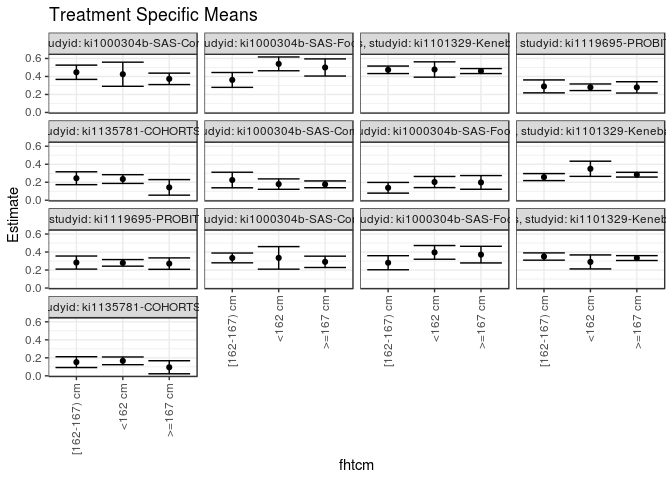

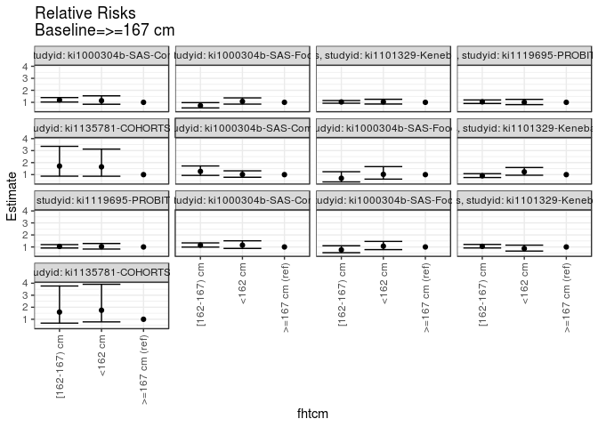

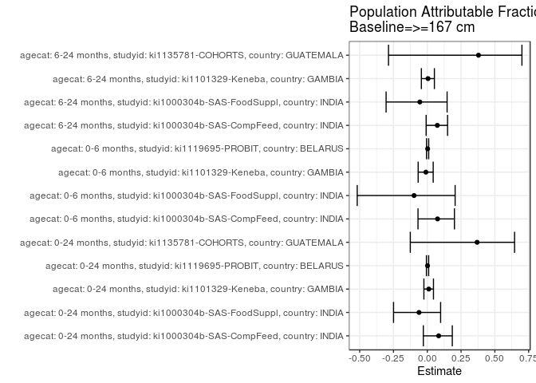

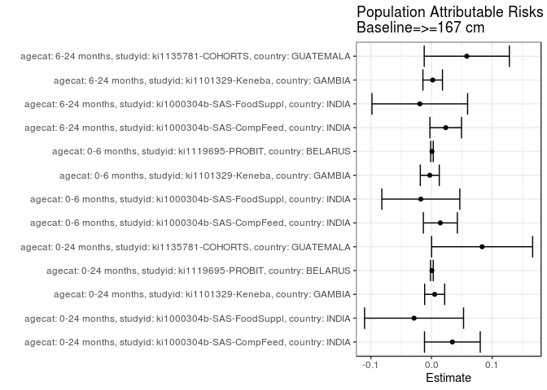

## Results Table

### Parameter: TSM

| agecat | studyid | country | intervention_level | baseline_level | estimate | ci_lower | ci_upper |
| --- | --- | --- | --- | --- | --- | --- | --- |
| 0-24 months | ki1000304b-SAS-CompFeed | INDIA | >=167 cm | NA | 0.3734644 | 0.3098827 | 0.4370461 |
| 0-24 months | ki1000304b-SAS-CompFeed | INDIA | <162 cm | NA | 0.4247788 | 0.2907944 | 0.5587632 |
| 0-24 months | ki1000304b-SAS-CompFeed | INDIA | [162-167) cm | NA | 0.4465649 | 0.3672291 | 0.5259007 |
| 0-24 months | ki1000304b-SAS-FoodSuppl | INDIA | >=167 cm | NA | 0.5000000 | 0.4046962 | 0.5953038 |
| 0-24 months | ki1000304b-SAS-FoodSuppl | INDIA | <162 cm | NA | 0.5398773 | 0.4632676 | 0.6164870 |
| 0-24 months | ki1000304b-SAS-FoodSuppl | INDIA | [162-167) cm | NA | 0.3615385 | 0.2788460 | 0.4442309 |
| 0-24 months | ki1101329-Keneba | GAMBIA | >=167 cm | NA | 0.4599359 | 0.4322777 | 0.4875941 |
| 0-24 months | ki1101329-Keneba | GAMBIA | <162 cm | NA | 0.4772727 | 0.3920424 | 0.5625031 |
| 0-24 months | ki1101329-Keneba | GAMBIA | [162-167) cm | NA | 0.4737794 | 0.4321529 | 0.5154059 |
| 0-24 months | ki1119695-PROBIT | BELARUS | >=167 cm | NA | 0.2786955 | 0.2159099 | 0.3414811 |
| 0-24 months | ki1119695-PROBIT | BELARUS | <162 cm | NA | 0.2797619 | 0.2431554 | 0.3163684 |
| 0-24 months | ki1119695-PROBIT | BELARUS | [162-167) cm | NA | 0.2896000 | 0.2178061 | 0.3613939 |
| 0-24 months | ki1135781-COHORTS | GUATEMALA | >=167 cm | NA | 0.1428571 | 0.0563614 | 0.2293528 |
| 0-24 months | ki1135781-COHORTS | GUATEMALA | <162 cm | NA | 0.2354949 | 0.1868615 | 0.2841282 |
| 0-24 months | ki1135781-COHORTS | GUATEMALA | [162-167) cm | NA | 0.2446043 | 0.1730725 | 0.3161361 |
| 0-6 months | ki1000304b-SAS-CompFeed | INDIA | >=167 cm | NA | 0.1769042 | 0.1391685 | 0.2146399 |
| 0-6 months | ki1000304b-SAS-CompFeed | INDIA | <162 cm | NA | 0.1793722 | 0.1216647 | 0.2370797 |
| 0-6 months | ki1000304b-SAS-CompFeed | INDIA | [162-167) cm | NA | 0.2248062 | 0.1384005 | 0.3112119 |
| 0-6 months | ki1000304b-SAS-FoodSuppl | INDIA | >=167 cm | NA | 0.1981132 | 0.1221413 | 0.2740852 |
| 0-6 months | ki1000304b-SAS-FoodSuppl | INDIA | <162 cm | NA | 0.2024540 | 0.1406893 | 0.2642187 |
| 0-6 months | ki1000304b-SAS-FoodSuppl | INDIA | [162-167) cm | NA | 0.1384615 | 0.0790155 | 0.1979076 |
| 0-6 months | ki1101329-Keneba | GAMBIA | >=167 cm | NA | 0.2840502 | 0.2575846 | 0.3105157 |
| 0-6 months | ki1101329-Keneba | GAMBIA | <162 cm | NA | 0.3495935 | 0.2652997 | 0.4338873 |
| 0-6 months | ki1101329-Keneba | GAMBIA | [162-167) cm | NA | 0.2572016 | 0.2183304 | 0.2960729 |
| 0-6 months | ki1119695-PROBIT | BELARUS | >=167 cm | NA | 0.2713726 | 0.2079737 | 0.3347715 |
| 0-6 months | ki1119695-PROBIT | BELARUS | <162 cm | NA | 0.2797619 | 0.2431554 | 0.3163684 |
| 0-6 months | ki1119695-PROBIT | BELARUS | [162-167) cm | NA | 0.2832000 | 0.2106698 | 0.3557302 |
| 6-24 months | ki1000304b-SAS-CompFeed | INDIA | >=167 cm | NA | 0.2912371 | 0.2281039 | 0.3543703 |
| 6-24 months | ki1000304b-SAS-CompFeed | INDIA | <162 cm | NA | 0.3350000 | 0.2095927 | 0.4604073 |
| 6-24 months | ki1000304b-SAS-CompFeed | INDIA | [162-167) cm | NA | 0.3346774 | 0.2801832 | 0.3891716 |
| 6-24 months | ki1000304b-SAS-FoodSuppl | INDIA | >=167 cm | NA | 0.3714286 | 0.2788899 | 0.4639672 |
| 6-24 months | ki1000304b-SAS-FoodSuppl | INDIA | <162 cm | NA | 0.3962264 | 0.3201039 | 0.4723489 |
| 6-24 months | ki1000304b-SAS-FoodSuppl | INDIA | [162-167) cm | NA | 0.2812500 | 0.2032611 | 0.3592389 |
| 6-24 months | ki1101329-Keneba | GAMBIA | >=167 cm | NA | 0.3330523 | 0.3062220 | 0.3598826 |
| 6-24 months | ki1101329-Keneba | GAMBIA | <162 cm | NA | 0.2900763 | 0.2123458 | 0.3678069 |
| 6-24 months | ki1101329-Keneba | GAMBIA | [162-167) cm | NA | 0.3501873 | 0.3097167 | 0.3906578 |
| 6-24 months | ki1135781-COHORTS | GUATEMALA | >=167 cm | NA | 0.0952381 | 0.0226785 | 0.1677977 |
| 6-24 months | ki1135781-COHORTS | GUATEMALA | <162 cm | NA | 0.1666667 | 0.1235813 | 0.2097521 |
| 6-24 months | ki1135781-COHORTS | GUATEMALA | [162-167) cm | NA | 0.1521739 | 0.0921842 | 0.2121636 |

### Parameter: E(Y)

| agecat | studyid | country | intervention_level | baseline_level | estimate | ci_lower | ci_upper |
| --- | --- | --- | --- | --- | --- | --- | --- |
| 0-24 months | ki1000304b-SAS-CompFeed | INDIA | NA | NA | 0.4078212 | 0.3382171 | 0.4774254 |
| 0-24 months | ki1000304b-SAS-FoodSuppl | INDIA | NA | NA | 0.4711779 | 0.4221376 | 0.5202183 |
| 0-24 months | ki1101329-Keneba | GAMBIA | NA | NA | 0.4650802 | 0.4428393 | 0.4873211 |
| 0-24 months | ki1119695-PROBIT | BELARUS | NA | NA | 0.2792534 | 0.2170833 | 0.3414235 |
| 0-24 months | ki1135781-COHORTS | GUATEMALA | NA | NA | 0.2262626 | 0.1893659 | 0.2631594 |
| 0-6 months | ki1000304b-SAS-CompFeed | INDIA | NA | NA | 0.1914414 | 0.1418556 | 0.2410273 |
| 0-6 months | ki1000304b-SAS-FoodSuppl | INDIA | NA | NA | 0.1804511 | 0.1426701 | 0.2182322 |
| 0-6 months | ki1101329-Keneba | GAMBIA | NA | NA | 0.2811594 | 0.2599381 | 0.3023807 |
| 0-6 months | ki1119695-PROBIT | BELARUS | NA | NA | 0.2720747 | 0.2092007 | 0.3349486 |
| 6-24 months | ki1000304b-SAS-CompFeed | INDIA | NA | NA | 0.3145933 | 0.2482331 | 0.3809535 |
| 6-24 months | ki1000304b-SAS-FoodSuppl | INDIA | NA | NA | 0.3520408 | 0.3047006 | 0.3993810 |
| 6-24 months | ki1101329-Keneba | GAMBIA | NA | NA | 0.3349541 | 0.3134470 | 0.3564611 |
| 6-24 months | ki1135781-COHORTS | GUATEMALA | NA | NA | 0.1533742 | 0.1214029 | 0.1853455 |

### Parameter: RR

| agecat | studyid | country | intervention_level | baseline_level | estimate | ci_lower | ci_upper |
| --- | --- | --- | --- | --- | --- | --- | --- |
| 0-24 months | ki1000304b-SAS-CompFeed | INDIA | >=167 cm | >=167 cm | 1.0000000 | 1.0000000 | 1.000000 |
| 0-24 months | ki1000304b-SAS-CompFeed | INDIA | <162 cm | >=167 cm | 1.1374010 | 0.8398275 | 1.540413 |
| 0-24 months | ki1000304b-SAS-CompFeed | INDIA | [162-167) cm | >=167 cm | 1.1957362 | 1.0246383 | 1.395405 |
| 0-24 months | ki1000304b-SAS-FoodSuppl | INDIA | >=167 cm | >=167 cm | 1.0000000 | 1.0000000 | 1.000000 |
| 0-24 months | ki1000304b-SAS-FoodSuppl | INDIA | <162 cm | >=167 cm | 1.0797546 | 0.8513815 | 1.369386 |
| 0-24 months | ki1000304b-SAS-FoodSuppl | INDIA | [162-167) cm | >=167 cm | 0.7230769 | 0.5368835 | 0.973843 |
| 0-24 months | ki1101329-Keneba | GAMBIA | >=167 cm | >=167 cm | 1.0000000 | 1.0000000 | 1.000000 |
| 0-24 months | ki1101329-Keneba | GAMBIA | <162 cm | >=167 cm | 1.0376940 | 0.8594779 | 1.252864 |
| 0-24 months | ki1101329-Keneba | GAMBIA | [162-167) cm | >=167 cm | 1.0300987 | 0.9260616 | 1.145824 |
| 0-24 months | ki1119695-PROBIT | BELARUS | >=167 cm | >=167 cm | 1.0000000 | 1.0000000 | 1.000000 |
| 0-24 months | ki1119695-PROBIT | BELARUS | <162 cm | >=167 cm | 1.0038264 | 0.8094969 | 1.244807 |
| 0-24 months | ki1119695-PROBIT | BELARUS | [162-167) cm | >=167 cm | 1.0391269 | 0.9029993 | 1.195776 |
| 0-24 months | ki1135781-COHORTS | GUATEMALA | >=167 cm | >=167 cm | 1.0000000 | 1.0000000 | 1.000000 |
| 0-24 months | ki1135781-COHORTS | GUATEMALA | <162 cm | >=167 cm | 1.6484642 | 0.8694655 | 3.125408 |
| 0-24 months | ki1135781-COHORTS | GUATEMALA | [162-167) cm | >=167 cm | 1.7122302 | 0.8740675 | 3.354126 |
| 0-6 months | ki1000304b-SAS-CompFeed | INDIA | >=167 cm | >=167 cm | 1.0000000 | 1.0000000 | 1.000000 |
| 0-6 months | ki1000304b-SAS-CompFeed | INDIA | <162 cm | >=167 cm | 1.0139512 | 0.7805718 | 1.317108 |
| 0-6 months | ki1000304b-SAS-CompFeed | INDIA | [162-167) cm | >=167 cm | 1.2707795 | 0.9378504 | 1.721896 |
| 0-6 months | ki1000304b-SAS-FoodSuppl | INDIA | >=167 cm | >=167 cm | 1.0000000 | 1.0000000 | 1.000000 |
| 0-6 months | ki1000304b-SAS-FoodSuppl | INDIA | <162 cm | >=167 cm | 1.0219106 | 0.6260310 | 1.668130 |
| 0-6 months | ki1000304b-SAS-FoodSuppl | INDIA | [162-167) cm | >=167 cm | 0.6989011 | 0.3930165 | 1.242855 |
| 0-6 months | ki1101329-Keneba | GAMBIA | >=167 cm | >=167 cm | 1.0000000 | 1.0000000 | 1.000000 |
| 0-6 months | ki1101329-Keneba | GAMBIA | <162 cm | >=167 cm | 1.2307456 | 0.9503977 | 1.593790 |
| 0-6 months | ki1101329-Keneba | GAMBIA | [162-167) cm | >=167 cm | 0.9054796 | 0.7581803 | 1.081396 |
| 0-6 months | ki1119695-PROBIT | BELARUS | >=167 cm | >=167 cm | 1.0000000 | 1.0000000 | 1.000000 |
| 0-6 months | ki1119695-PROBIT | BELARUS | <162 cm | >=167 cm | 1.0309143 | 0.8264062 | 1.286031 |
| 0-6 months | ki1119695-PROBIT | BELARUS | [162-167) cm | >=167 cm | 1.0435836 | 0.9122510 | 1.193823 |
| 6-24 months | ki1000304b-SAS-CompFeed | INDIA | >=167 cm | >=167 cm | 1.0000000 | 1.0000000 | 1.000000 |
| 6-24 months | ki1000304b-SAS-CompFeed | INDIA | <162 cm | >=167 cm | 1.1502655 | 0.8763443 | 1.509807 |
| 6-24 months | ki1000304b-SAS-CompFeed | INDIA | [162-167) cm | >=167 cm | 1.1491579 | 0.9872806 | 1.337577 |
| 6-24 months | ki1000304b-SAS-FoodSuppl | INDIA | >=167 cm | >=167 cm | 1.0000000 | 1.0000000 | 1.000000 |
| 6-24 months | ki1000304b-SAS-FoodSuppl | INDIA | <162 cm | >=167 cm | 1.0667634 | 0.7788132 | 1.461177 |
| 6-24 months | ki1000304b-SAS-FoodSuppl | INDIA | [162-167) cm | >=167 cm | 0.7572115 | 0.5215807 | 1.099292 |
| 6-24 months | ki1101329-Keneba | GAMBIA | >=167 cm | >=167 cm | 1.0000000 | 1.0000000 | 1.000000 |
| 6-24 months | ki1101329-Keneba | GAMBIA | <162 cm | >=167 cm | 0.8709634 | 0.6583829 | 1.152182 |
| 6-24 months | ki1101329-Keneba | GAMBIA | [162-167) cm | >=167 cm | 1.0514483 | 0.9132859 | 1.210512 |
| 6-24 months | ki1135781-COHORTS | GUATEMALA | >=167 cm | >=167 cm | 1.0000000 | 1.0000000 | 1.000000 |
| 6-24 months | ki1135781-COHORTS | GUATEMALA | <162 cm | >=167 cm | 1.7499999 | 0.7827645 | 3.912415 |
| 6-24 months | ki1135781-COHORTS | GUATEMALA | [162-167) cm | >=167 cm | 1.5978260 | 0.6776121 | 3.767713 |

### Parameter: PAR

| agecat | studyid | country | intervention_level | baseline_level | estimate | ci_lower | ci_upper |
| --- | --- | --- | --- | --- | --- | --- | --- |
| 0-24 months | ki1000304b-SAS-CompFeed | INDIA | >=167 cm | NA | 0.0343569 | -0.0115936 | 0.0803073 |
| 0-24 months | ki1000304b-SAS-FoodSuppl | INDIA | >=167 cm | NA | -0.0288221 | -0.1104420 | 0.0527979 |
| 0-24 months | ki1101329-Keneba | GAMBIA | >=167 cm | NA | 0.0051443 | -0.0113437 | 0.0216323 |
| 0-24 months | ki1119695-PROBIT | BELARUS | >=167 cm | NA | 0.0005579 | -0.0017208 | 0.0028366 |
| 0-24 months | ki1135781-COHORTS | GUATEMALA | >=167 cm | NA | 0.0834055 | 0.0001079 | 0.1667031 |
| 0-6 months | ki1000304b-SAS-CompFeed | INDIA | >=167 cm | NA | 0.0145373 | -0.0134900 | 0.0425645 |
| 0-6 months | ki1000304b-SAS-FoodSuppl | INDIA | >=167 cm | NA | -0.0176621 | -0.0819463 | 0.0466221 |
| 0-6 months | ki1101329-Keneba | GAMBIA | >=167 cm | NA | -0.0028908 | -0.0185266 | 0.0127451 |
| 0-6 months | ki1119695-PROBIT | BELARUS | >=167 cm | NA | 0.0007020 | -0.0014324 | 0.0028365 |
| 6-24 months | ki1000304b-SAS-CompFeed | INDIA | >=167 cm | NA | 0.0233562 | -0.0026871 | 0.0493995 |
| 6-24 months | ki1000304b-SAS-FoodSuppl | INDIA | >=167 cm | NA | -0.0193878 | -0.0982354 | 0.0594599 |
| 6-24 months | ki1101329-Keneba | GAMBIA | >=167 cm | NA | 0.0019018 | -0.0142206 | 0.0180242 |
| 6-24 months | ki1135781-COHORTS | GUATEMALA | >=167 cm | NA | 0.0581361 | -0.0120811 | 0.1283534 |

### Parameter: PAF

| agecat | studyid | country | intervention_level | baseline_level | estimate | ci_lower | ci_upper |
| --- | --- | --- | --- | --- | --- | --- | --- |
| 0-24 months | ki1000304b-SAS-CompFeed | INDIA | >=167 cm | NA | 0.0842449 | -0.0291369 | 0.1851352 |
| 0-24 months | ki1000304b-SAS-FoodSuppl | INDIA | >=167 cm | NA | -0.0611702 | -0.2494586 | 0.0987439 |
| 0-24 months | ki1101329-Keneba | GAMBIA | >=167 cm | NA | 0.0110611 | -0.0250369 | 0.0458878 |
| 0-24 months | ki1119695-PROBIT | BELARUS | >=167 cm | NA | 0.0019978 | -0.0063204 | 0.0102473 |
| 0-24 months | ki1135781-COHORTS | GUATEMALA | >=167 cm | NA | 0.3686224 | -0.1255915 | 0.6458417 |
| 0-6 months | ki1000304b-SAS-CompFeed | INDIA | >=167 cm | NA | 0.0759358 | -0.0686662 | 0.2009717 |
| 0-6 months | ki1000304b-SAS-FoodSuppl | INDIA | >=167 cm | NA | -0.0978774 | -0.5182879 | 0.2061224 |
| 0-6 months | ki1101329-Keneba | GAMBIA | >=167 cm | NA | -0.0102816 | -0.0674515 | 0.0438265 |
| 0-6 months | ki1119695-PROBIT | BELARUS | >=167 cm | NA | 0.0025803 | -0.0054550 | 0.0105515 |
| 6-24 months | ki1000304b-SAS-CompFeed | INDIA | >=167 cm | NA | 0.0742425 | -0.0084685 | 0.1501698 |
| 6-24 months | ki1000304b-SAS-FoodSuppl | INDIA | >=167 cm | NA | -0.0550725 | -0.3046159 | 0.1467390 |
| 6-24 months | ki1101329-Keneba | GAMBIA | >=167 cm | NA | 0.0056778 | -0.0436395 | 0.0526646 |
| 6-24 months | ki1135781-COHORTS | GUATEMALA | >=167 cm | NA | 0.3790476 | -0.2868794 | 0.7003745 |